# Zantiks manipulation scripts

```r
library(tidyverse)
library(lme4)
library(MCMCglmm)
library(here) # write out the path
```

# Locomotion

## Data parsing

First let’s test-load one data file to see how to trim it into relevant bits. Definition in this files is so that first 4 rows and firts 6 columns are redundant.

The first portion loads and parses the raw data file lines.

```r
data_path <- here("Data/locomotion/")
data_path <- paste0(data_path, "/") #need this when using PC. Don't use on Mac
data_files <- list.files(here("Data/locomotion/"), recursive = T)
head(data_files)
```

```
## [1] "E_locomotion_traking-20000228T224844.csv"
## [2] "E_locomotion_traking-20000229T005421.csv"
## [3] "E_locomotion_traking-20000229T031017.csv"
## [4] "E_locomotion_traking-20000229T043418.csv"
## [5] "E_locomotion_traking-20000229T224459.csv"
## [6] "E_locomotion_traking-20000301T001741.csv"
```

```r
# read in one specific file in mac
#dat_temp = readLines(paste(data_path, data_files[2], sep = ''))

# read in one specific file in PC
dat_temp <- readLines(paste(data_path, '/', data_files[2], sep = ''))

dat_temp_df <- read.csv(text = dat_temp, header = T, sep = ',',
                        quote = '\"', dec = '.', skip = 4, nrows = length(dat_temp) - 4 - 2,
                        stringsAsFactors = F)
# altearntive should work too
#dat_temp_df2 <- read.csv(file = here("Data", "locomotion", data_files[2]), header = T,  skip = 4)

dat_temp_df = dat_temp_df[, -(2:6)]
dat_temp_df = dat_temp_df %>% select(!(F6:F8))
dat_temp_df
```

```
##       TIME TEMPERATURE ROUND         VARIABLE   A1    A2    A3  A4  A5 A6   A7
## 1  964.295       24.60     1 BINARENADISTANCE  1.6  30.4  14.2 1.4 3.0  0 11.8
## 2 1324.299       25.04     2 BINARENADISTANCE  3.2 204.5  10.4 0.0 3.0  0 12.3
## 3 1684.303       24.96     3 BINARENADISTANCE  8.8  16.5  76.8 3.0 6.3  0 16.5
## 4 2044.314       24.96     4 BINARENADISTANCE  1.6  23.0 140.4 4.4 2.8  0 32.7
## 5 2404.317       24.78     5 BINARENADISTANCE 59.2  57.8  93.5 0.0 6.0  0 28.5
##     A8    B1   B2 B3  B4     B5    B6    B7   B8   C1 C2  C3  C4   C5    C6
## 1  0.0   1.4  5.8  0 4.4    8.8   7.2   0.0  4.4  5.8  0 1.4 3.0  1.4   1.6
## 2  0.0  20.9  8.8  0 4.4   40.8   8.8   3.2 15.8 10.2  0 0.0 3.0  7.9   9.1
## 3  4.4  17.4 13.7  0 3.0  448.4  23.2  19.7  6.0 10.7  0 0.0 1.4 21.4 209.6
## 4  8.1   3.0  0.0  0 8.8  861.1  68.5  18.1 10.2 10.7  0 1.6 4.2 15.3  85.4
## 5 14.4 296.9 27.4  0 8.8 1415.4 101.7 148.8 16.7 64.5  0 0.0 0.0 11.8 246.3
##     C7   C8   D1   D2  D3  D4   D5 D6   D7   D8   E1  E2  E3   E4  E5   E6   E7
## 1  1.4  0.0  0.0  8.8 0.0 1.4  1.4  0  4.4  9.1  7.7 4.4 0.0  0.0 1.4  2.8  1.6
## 2  2.8  3.2  3.0  8.8 0.0 0.0  4.4  0 10.4 11.6  6.0 0.0 1.4  3.0 1.4 11.8  1.4
## 3 20.0  1.6 15.6 11.6 4.4 3.0  6.0  0 11.6 12.1  3.2 5.8 0.0  1.4 4.4 14.9  3.0
## 4  8.1 31.8 13.5 24.1 1.4 4.4  4.4  0 15.6 10.7 21.1 9.1 1.4  1.4 1.4 23.2  4.6
## 5  6.0 32.5 61.5  9.3 7.2 3.2 41.3  0 37.8  6.0 32.0 3.0 0.0 10.7 7.2 20.7 12.1
##     E8   F1    F2   F3  F4  F5
## 1  7.4 10.4   1.4  3.0 1.4 1.4
## 2  7.2  5.8   4.4 10.2 3.0 1.4
## 3 10.2  4.9   8.8  9.1 0.0 4.4
## 4  7.4 95.4 157.1 10.4 5.8 3.0
## 5  0.0 32.7 152.7  9.1 1.4 4.9
```

Here we extract and append the run (subject) ID.

```r
head_temp <- read_csv(file = paste(data_path, data_files[1], sep = ''))
#Szymek old code: id_index = grep('Subject Identification', head_temp)
#id_index = grep('.*Subject Identification\\\",\\\"([A-Z0-9]{7}_[A-B0-9_]*)\\\"', head_temp)
#run_id = gsub('.*Subject Identification\\",\\"([A-Z0-9]{7}_[A-B0-9_]*)\\"', '\\1', head_temp[id_index])

dat_temp_df$run_id  <- head_temp[[4]][1]


run_id <- head_temp[[4]][1]
assay_date <- str_sub(run_id, 11, 16)

#assay_date = gsub('([0-9]{6})/E_[A-Za-z_]+-[0-9A-Z]+.csv', '\\1', data_files[1])
dat_temp_df$date = assay_date
dat_temp_df
```

```
##       TIME TEMPERATURE ROUND         VARIABLE   A1    A2    A3  A4  A5 A6   A7
## 1  964.295       24.60     1 BINARENADISTANCE  1.6  30.4  14.2 1.4 3.0  0 11.8
## 2 1324.299       25.04     2 BINARENADISTANCE  3.2 204.5  10.4 0.0 3.0  0 12.3
## 3 1684.303       24.96     3 BINARENADISTANCE  8.8  16.5  76.8 3.0 6.3  0 16.5
## 4 2044.314       24.96     4 BINARENADISTANCE  1.6  23.0 140.4 4.4 2.8  0 32.7
## 5 2404.317       24.78     5 BINARENADISTANCE 59.2  57.8  93.5 0.0 6.0  0 28.5
##     A8    B1   B2 B3  B4     B5    B6    B7   B8   C1 C2  C3  C4   C5    C6
## 1  0.0   1.4  5.8  0 4.4    8.8   7.2   0.0  4.4  5.8  0 1.4 3.0  1.4   1.6
## 2  0.0  20.9  8.8  0 4.4   40.8   8.8   3.2 15.8 10.2  0 0.0 3.0  7.9   9.1
## 3  4.4  17.4 13.7  0 3.0  448.4  23.2  19.7  6.0 10.7  0 0.0 1.4 21.4 209.6
## 4  8.1   3.0  0.0  0 8.8  861.1  68.5  18.1 10.2 10.7  0 1.6 4.2 15.3  85.4
## 5 14.4 296.9 27.4  0 8.8 1415.4 101.7 148.8 16.7 64.5  0 0.0 0.0 11.8 246.3
##     C7   C8   D1   D2  D3  D4   D5 D6   D7   D8   E1  E2  E3   E4  E5   E6   E7
## 1  1.4  0.0  0.0  8.8 0.0 1.4  1.4  0  4.4  9.1  7.7 4.4 0.0  0.0 1.4  2.8  1.6
## 2  2.8  3.2  3.0  8.8 0.0 0.0  4.4  0 10.4 11.6  6.0 0.0 1.4  3.0 1.4 11.8  1.4
## 3 20.0  1.6 15.6 11.6 4.4 3.0  6.0  0 11.6 12.1  3.2 5.8 0.0  1.4 4.4 14.9  3.0
## 4  8.1 31.8 13.5 24.1 1.4 4.4  4.4  0 15.6 10.7 21.1 9.1 1.4  1.4 1.4 23.2  4.6
## 5  6.0 32.5 61.5  9.3 7.2 3.2 41.3  0 37.8  6.0 32.0 3.0 0.0 10.7 7.2 20.7 12.1
##     E8   F1    F2   F3  F4  F5             run_id   date
## 1  7.4 10.4   1.4  3.0 1.4 1.4 Z0107D3_B_210421_1 210421
## 2  7.2  5.8   4.4 10.2 3.0 1.4 Z0107D3_B_210421_1 210421
## 3 10.2  4.9   8.8  9.1 0.0 4.4 Z0107D3_B_210421_1 210421
## 4  7.4 95.4 157.1 10.4 5.8 3.0 Z0107D3_B_210421_1 210421
## 5  0.0 32.7 152.7  9.1 1.4 4.9 Z0107D3_B_210421_1 210421
```

Change to long format with individual IDs formed by merging plate ID and run ID.

```r
dat_temp_df <-
  dat_temp_df %>%
  pivot_longer(names_to = 'well_id', values_to = 'arena_distance', cols = matches('[A-H][1-9]')) %>%
  unite(col = 'indiv_id', c(run_id, well_id), sep = '_', remove = F)

# removing machine ID
dat_temp_df$indiv_id <-   str_sub(dat_temp_df$indiv_id, 11)
# adding ID_
dat_temp_df$indiv_id <- paste0("ID_", dat_temp_df$indiv_id)

dat_temp_df
```

```
## # A tibble: 225 x 9
##     TIME TEMPERATURE ROUND VARIABLE indiv_id run_id date  well_id arena_distance
##    <dbl>       <dbl> <int> <chr>    <chr>    <chr>  <chr> <chr>            <dbl>
##  1  964.        24.6     1 BINAREN… ID_2104… Z0107… 2104… A1                 1.6
##  2  964.        24.6     1 BINAREN… ID_2104… Z0107… 2104… A2                30.4
##  3  964.        24.6     1 BINAREN… ID_2104… Z0107… 2104… A3                14.2
##  4  964.        24.6     1 BINAREN… ID_2104… Z0107… 2104… A4                 1.4
##  5  964.        24.6     1 BINAREN… ID_2104… Z0107… 2104… A5                 3
##  6  964.        24.6     1 BINAREN… ID_2104… Z0107… 2104… A6                 0
##  7  964.        24.6     1 BINAREN… ID_2104… Z0107… 2104… A7                11.8
##  8  964.        24.6     1 BINAREN… ID_2104… Z0107… 2104… A8                 0
##  9  964.        24.6     1 BINAREN… ID_2104… Z0107… 2104… B1                 1.4
## 10  964.        24.6     1 BINAREN… ID_2104… Z0107… 2104… B2                 5.8
## # … with 215 more rows
```

Writing a function and using map to apply data loading and wrangling to all files

```r
#dat_df <- NULL
#for (file_i in data_files) {

  # file parsing
 # dat_temp = readLines(paste(data_path, file_i, sep = ''))
  #dat_temp_df = read.csv(text = dat_temp, header = T, sep = ',',
                        # quote = '\"', dec = '.', skip = 4, nrows = length(dat_temp) - 4 - 2,
                         #stringsAsFactors = F)
  #dat_temp_df = dat_temp_df[, -(2:6)]
  #dat_temp_df = dat_temp_df %>% select(!(F6:F8))

  # extract headers
  #head_temp <- read_csv(file = paste(data_path, data_files[1], sep = ''))
  #id_index = grep('Subject Identification', head_temp)
  # ask Szymek to tell us what this all mean
  #id_index = grep('.*Subject Identification\\\",\\\"([A-Z0-9]{7}_[A-B0-9_]*)\\\"', head_temp)
  #run_id = gsub('.*Subject Identification\\",\\"([A-Z0-9]{7}_[A-B0-9_]*)\\"', '\\1', head_temp[id_index])
  #dat_temp_df$run_id <- head_temp[[4]][1]

  #assay_date = gsub('([0-9]{6})/E_[A-Za-z_]+-[0-9A-Z]+.csv', '\\1', data_files[1])
  #dat_temp_df$date = assay_date
  #dat_temp_df

  # tidy
  #dat_temp_df <-
  #dat_temp_df %>%
  #pivot_longer(names_to = 'well_id', values_to = 'arena_distance', cols = matches('[A-H][1-9]')) %>%
  #unite(col = 'indiv_id', c(run_id, well_id), sep = '_', remove = F)

   # removing machine ID
   #dat_temp_df$indiv_id <-   str_sub(dat_temp_df$indiv_id, 11)
   # adding ID_
   #dat_temp_df$indiv_id <- paste0("ID_", dat_temp_df$indiv_id)

   #dat_temp_df

  # merge into larger file
  #if(is.null(dat_df))
   # {dat_df = dat_temp_df
  #} else{
    #dat_df = rbind(dat_df, dat_temp_df)}
#}

#dat_df

# function
#210422/E_locomotion_traking-20000228T224844.csv

data_compiler <- function(data.name = "", data_path =data_path){
    # file parsing
  dat_temp <- readLines(paste(data_path, data.name, sep = ''))
  dat_temp_df <- read.csv(text = dat_temp, header = T, sep = ',',
                         quote = '\"', dec = '.', skip = 4, nrows = length(dat_temp) - 4 - 2,
                         stringsAsFactors = F)
  dat_temp_df <- dat_temp_df[, -(2:6)]
  dat_temp_df <- dat_temp_df %>% select(!(F6:F8))

  # extract headers
  head_temp <- read_csv(file = paste(data_path, data.name, sep = ''))

  dat_temp_df$run_id <- head_temp[[4]][1]

run_id <- head_temp[[4]][1]
assay_date <- str_sub(run_id, 11, 16)

 dat_temp_df$date = assay_date
 dat_temp_df

  dat_temp_df <-
  dat_temp_df %>%
  pivot_longer(names_to = 'well_id', values_to = 'arena_distance', cols = matches('[A-H][1-9]')) %>%
  unite(col = 'indiv_id', c(run_id, well_id), sep = '_', remove = F)

  # removing machine ID
  dat_temp_df$indiv_id <-   str_sub(dat_temp_df$indiv_id, 11)
  # adding ID_
  dat_temp_df$indiv_id <- paste0("ID_", dat_temp_df$indiv_id)

  dat_temp_df

}

# map!
dat_df<- map_dfr(data_files, ~ data_compiler(.x, data_path =data_path))
```

##merging sex

```r
sex <- read_csv(here("Data", "sex", "Run register_Pilot 2 - Sex.csv"))
sex %>% transmute(indiv_id = paste(Indviduals_ID, Wellplate_location, sep = "_"), Sex = Sex) -> sex_dat

  # join together

dat_df2 <- dat_df %>% left_join(sex_dat)
```

## Simple viz

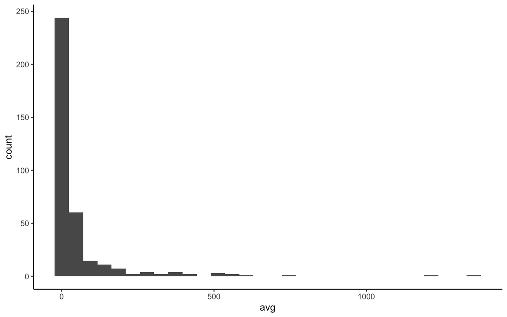

```r
dat_df_avg = dat_df2 %>%
  group_by(indiv_id) %>%
  summarise(avg = mean(arena_distance))

# raw data variation
dat_df_avg %>%
  ggplot(aes(x = avg)) +
  geom_histogram() +
  theme_classic()
```

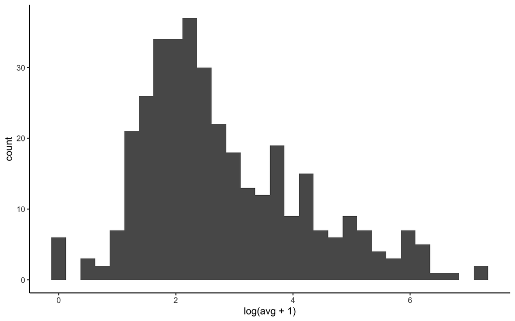

```r
# log scale
dat_df_avg %>%
  ggplot(aes(x = log(avg+1))) +
  geom_histogram() +
  theme_classic()
```

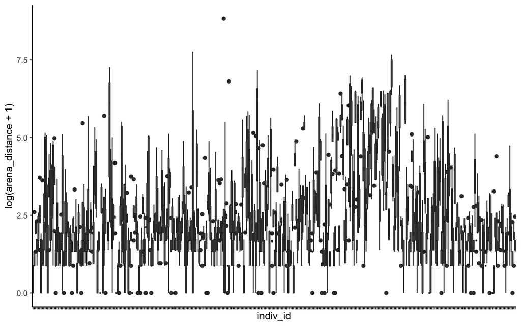

```r
dat_df2 %>%
  ggplot(aes(x = indiv_id, y = log(arena_distance+1))) +
  geom_boxplot() + theme_classic() + theme(axis.text.x = element_blank())
```

## Sex and temp differences, simple Viz and models

```r
#violin plot of distance grouped by sex
library(ggpubr)
dat_df3<- na.omit(dat_df2)

violin <-dat_df3 %>%
  group_by(indiv_id) %>%
  summarise(arena_distance = mean(arena_distance), Sex = unique(Sex)) %>%
  ggviolin(., x = "Sex", y = "arena_distance",add = c("jitter", "mean_se"), error.plot = "crossbar", palette= NULL)
#some huge outliers in females
pos_female <-which.max(dat_df3$arena_distance)
dat_df3[pos_female, ]
```

```
## # A tibble: 1 x 10
##    TIME TEMPERATURE ROUND VARIABLE  indiv_id run_id date  well_id arena_distance
##   <dbl>       <dbl> <int> <chr>     <chr>    <chr>  <chr> <chr>            <dbl>
## 1 2404.        24.8     5 BINARENA… ID_2104… Z0107… 2104… B5               1415.
## # … with 1 more variable: Sex <chr>
```

```r
dat_df3[dat_df3$indiv_id == "ID_210421_3_B5", ]
```

```
## # A tibble: 5 x 10
##    TIME TEMPERATURE ROUND VARIABLE  indiv_id run_id date  well_id arena_distance
##   <dbl>       <dbl> <int> <chr>     <chr>    <chr>  <chr> <chr>            <dbl>
## 1  964.        24.6     1 BINARENA… ID_2104… Z0107… 2104… B5                 8.8
## 2 1324.        25.0     2 BINARENA… ID_2104… Z0107… 2104… B5                40.8
## 3 1684.        25.0     3 BINARENA… ID_2104… Z0107… 2104… B5               448.
## 4 2044.        25.0     4 BINARENA… ID_2104… Z0107… 2104… B5               861.
## 5 2404.        24.8     5 BINARENA… ID_2104… Z0107… 2104… B5              1415.
## # … with 1 more variable: Sex <chr>
```

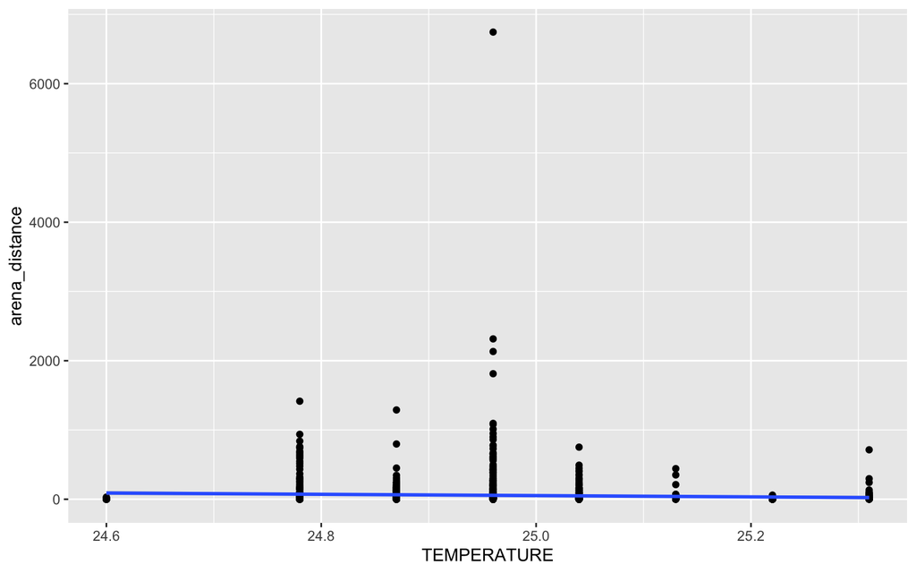

```r
#scatter plot of distance and temp

plot <- ggplot(dat_df2, aes(x = TEMPERATURE, y = arena_distance)) + geom_point() + geom_smooth(method = lm)

plot
```

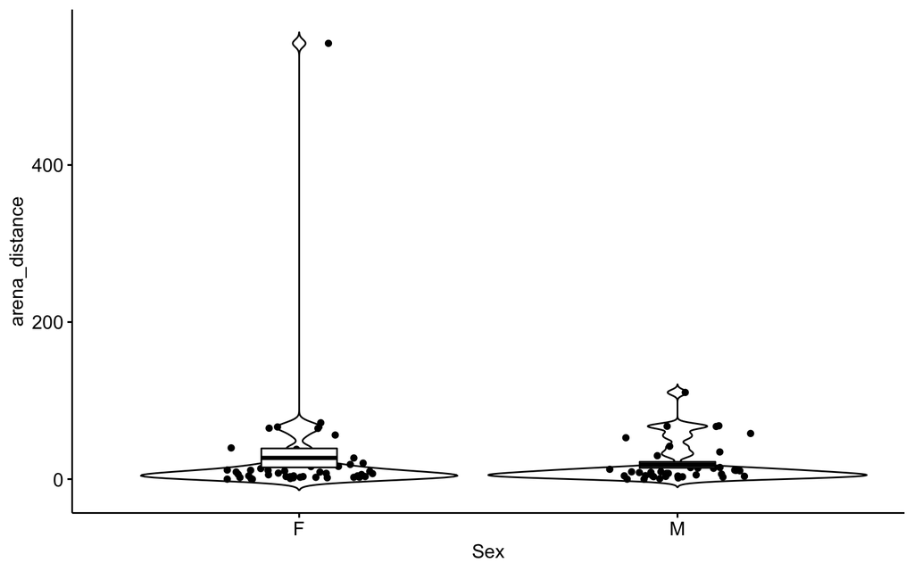

```r
violin
```

```r
#simple lmer

mod1 <- lmer(arena_distance~ Sex + TEMPERATURE + (1|indiv_id), data = dat_df3)
summary(mod1) # no difference between sex or temperature
```

```
## Linear mixed model fit by REML ['lmerMod']
## Formula: arena_distance ~ Sex + TEMPERATURE + (1 | indiv_id)
##    Data: dat_df3
##
## REML criterion at convergence: 5051.2
##
## Scaled residuals:
##     Min      1Q  Median      3Q     Max
## -5.4983 -0.1258 -0.0843 -0.0304 13.8539
##
## Random effects:
##  Groups   Name        Variance Std.Dev.
##  indiv_id (Intercept) 2792     52.84
##  Residual             5273     72.61
## Number of obs: 435, groups:  indiv_id, 87
##
## Fixed effects:
##             Estimate Std. Error t value
## (Intercept) -164.154    641.432  -0.256
## SexM          -8.711     13.325  -0.654
## TEMPERATURE    7.675     25.750   0.298
##
## Correlation of Fixed Effects:
##             (Intr) SexM
## SexM        -0.033
## TEMPERATURE -1.000  0.024
```

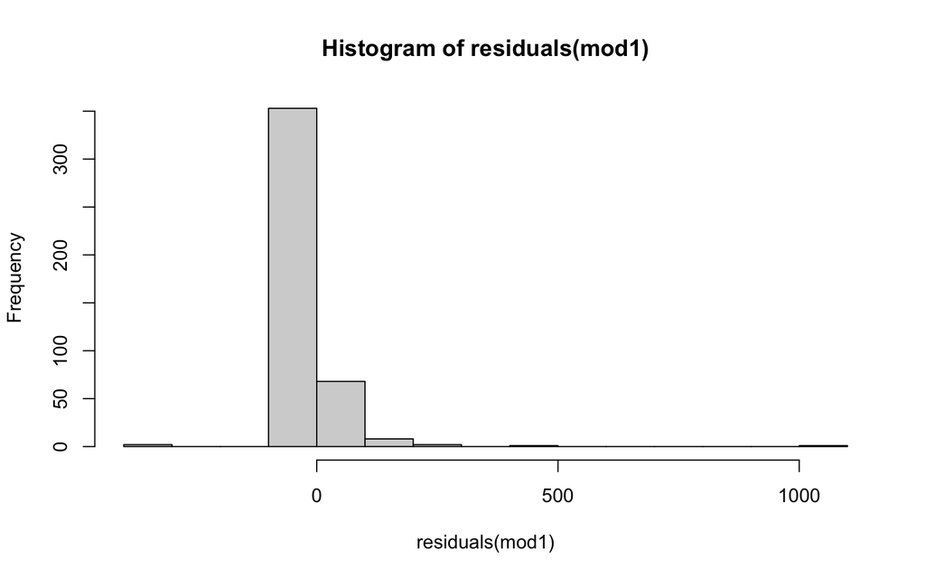

```r
hist(residuals(mod1), breaks = 20)
```

```r
# random intercept model
mod2 <- lmer(arena_distance~ Sex + TEMPERATURE + ROUND + (1|indiv_id), data = dat_df3)
summary(mod2) #
```

```
## Linear mixed model fit by REML ['lmerMod']
## Formula: arena_distance ~ Sex + TEMPERATURE + ROUND + (1 | indiv_id)
##    Data: dat_df3
##
## REML criterion at convergence: 5024.1
##
## Scaled residuals:
##     Min      1Q  Median      3Q     Max
## -5.5881 -0.2363 -0.0423  0.1356 13.7856
##
## Random effects:
##  Groups   Name        Variance Std.Dev.
##  indiv_id (Intercept) 2839     53.29
##  Residual             4948     70.34
## Number of obs: 435, groups:  indiv_id, 87
##
## Fixed effects:
##             Estimate Std. Error t value
## (Intercept)  694.483    646.117   1.075
## SexM          -9.151     13.294  -0.688
## TEMPERATURE  -28.270     26.021  -1.086
## ROUND         12.216      2.486   4.913
##
## Correlation of Fixed Effects:
##             (Intr) SexM   TEMPER
## SexM        -0.034
## TEMPERATURE -1.000  0.024
## ROUND        0.272 -0.007 -0.283
```

```r
# random slope model
mod3 <- lmer(arena_distance~ 1 + Sex + TEMPERATURE + ROUND + (1 + ROUND|indiv_id), data = dat_df3)
```

```
## boundary (singular) fit: see ?isSingular
```

```r
summary(mod3) #
```

```
## Linear mixed model fit by REML ['lmerMod']
## Formula: arena_distance ~ 1 + Sex + TEMPERATURE + ROUND + (1 + ROUND |
##     indiv_id)
##    Data: dat_df3
##
## REML criterion at convergence: 4512
##
## Scaled residuals:
##     Min      1Q  Median      3Q     Max
## -4.7008 -0.1811 -0.0399  0.0823  6.7433
##
## Random effects:
##  Groups   Name        Variance Std.Dev. Corr
##  indiv_id (Intercept) 3419.6   58.48
##           ROUND       1575.7   39.69    -1.00
##  Residual              962.7   31.03
## Number of obs: 435, groups:  indiv_id, 87
##
## Fixed effects:
##             Estimate Std. Error t value
## (Intercept) 594.7952   282.5006   2.105
## SexM         -0.1999     4.3197  -0.046
## TEMPERATURE -24.4234    11.3749  -2.147
## ROUND        12.1125     4.3946   2.756
##
## Correlation of Fixed Effects:
##             (Intr) SexM   TEMPER
## SexM        -0.041
## TEMPERATURE -1.000  0.034
## ROUND        0.046 -0.002 -0.070
## optimizer (nloptwrap) convergence code: 0 (OK)
## boundary (singular) fit: see ?isSingular
```

```r
#round is important as they move more during the assay. This increase differs between individuals


mod4 <- lmer(arena_distance~ Sex + TEMPERATURE + (1 + ROUND|indiv_id), data = dat_df3)
```

```
## boundary (singular) fit: see ?isSingular
```

```r
summary(mod4) #
```

```
## Linear mixed model fit by REML ['lmerMod']
## Formula: arena_distance ~ Sex + TEMPERATURE + (1 + ROUND | indiv_id)
##    Data: dat_df3
##
## REML criterion at convergence: 4524.2
##
## Scaled residuals:
##     Min      1Q  Median      3Q     Max
## -4.6883 -0.1886 -0.0438  0.0816  6.7551
##
## Random effects:
##  Groups   Name        Variance Std.Dev. Corr
##  indiv_id (Intercept) 3723.3   61.02
##           ROUND       1701.7   41.25    -1.00
##  Residual              963.3   31.04
## Number of obs: 435, groups:  indiv_id, 87
##
## Fixed effects:
##             Estimate Std. Error t value
## (Intercept) 562.8776   282.3241   1.994
## SexM         -0.1712     4.3168  -0.040
## TEMPERATURE -22.3799    11.3519  -1.971
##
## Correlation of Fixed Effects:
##             (Intr) SexM
## SexM        -0.041
## TEMPERATURE -1.000  0.034
## optimizer (nloptwrap) convergence code: 0 (OK)
## boundary (singular) fit: see ?isSingular
```

```r
ranef(mod4)
```

```
## $indiv_id
##                  (Intercept)        ROUND
## ID_210421_1_A1    1.32678628  -0.89696513
## ID_210421_1_A2    1.22822465  -0.83033319
## ID_210421_1_A3   -1.90697784   1.28919982
## ID_210421_1_A4   -0.13656639   0.09232481
## ID_210421_1_A5   -3.35405858   2.26748923
## ID_210421_1_A7    1.60335257  -1.08393596
## ID_210421_1_A8   -2.88365274   1.94947446
## ID_210421_1_B1   -5.76098948   3.89467903
## ID_210421_1_B2  -65.85953306  44.52390393
## ID_210421_1_B4   -7.18231834   4.85555905
## ID_210421_1_B5  -22.21208462  15.01633364
## ID_210421_1_B6  -27.97575350  18.91282405
## ID_210421_1_B7  -20.18327557  13.64477063
## ID_210421_1_B8  -48.71549274  32.93378828
## ID_210421_1_C1  -32.03055691  21.65404721
## ID_210421_1_C3   -8.87055023   5.99687711
## ID_210421_1_C4   -0.66808548   0.45165479
## ID_210421_1_C5    0.42098270  -0.28460259
## ID_210421_1_C6   -1.09570764   0.74074594
## ID_210421_1_C7  -53.28187630  36.02086184
## ID_210421_1_C8    0.86615383  -0.58555760
## ID_210421_1_D1  -13.51828936   9.13895056
## ID_210421_1_D2   -7.52861345   5.08966958
## ID_210421_1_D3   -1.38297089   0.93494837
## ID_210421_1_D4   -0.20898444   0.14128255
## ID_210421_1_D5   -0.58119941   0.39291604
## ID_210421_1_D6   -0.11972633   0.08094020
## ID_210421_1_D7   -2.45826182   1.66189173
## ID_210421_1_D8   -5.74205616   3.88187928
## ID_210421_1_E1   -2.30480736   1.55814985
## ID_210421_1_E2    0.88773386  -0.60014663
## ID_210421_1_E3   -3.17050959   2.14340214
## ID_210421_1_E4    0.84862300  -0.57370600
## ID_210421_1_E5    0.92380695  -0.62453361
## ID_210421_1_E6  -56.34291534  38.09025714
## ID_210421_1_E7   -6.94250966   4.69343797
## ID_210421_1_E8   -0.20660960   0.13967706
## ID_210421_1_F1   -1.24985569   0.84495672
```

[output cut: 36 more lines]

```
## ID_210421_3_E1   -8.65956709   5.85424335
## ID_210421_3_E2    0.02581623  -0.01745289
## ID_210421_3_E3    2.51613745  -1.70101816
## ID_210421_3_E4   -0.19991830   0.13515345
## ID_210421_3_E5    0.33229437  -0.22464542
## ID_210421_3_E6   -7.90231628   5.34230892
## ID_210421_3_E7   -1.21128474   0.81888108
## ID_210421_3_E8    0.41643268  -0.28152657
## ID_210421_3_F1  -21.42256424  14.48258358
## ID_210421_3_F2  -60.60719221  40.97309346
## ID_210421_3_F3   -2.36410381   1.59823682
## ID_210421_3_F4    1.43445594  -0.96975450
## ID_210421_3_F5    0.60397084  -0.40831051
##
## with conditional variances for "indiv_id"
```

## Mixed-model with between-individual variation

```r
model1 = lmer(log(arena_distance+1) ~ ROUND + date + (1|indiv_id) + (1|run_id),
              data = dat_df2)
summary(model1)
```

```
## Linear mixed model fit by REML ['lmerMod']
## Formula: log(arena_distance + 1) ~ ROUND + date + (1 | indiv_id) + (1 |
##     run_id)
##    Data: dat_df2
##
## REML criterion at convergence: 5688
##
## Scaled residuals:
##     Min      1Q  Median      3Q     Max
## -3.2192 -0.5706 -0.0177  0.5373  6.7653
##
## Random effects:
##  Groups   Name        Variance Std.Dev.
##  indiv_id (Intercept) 0.8484   0.9211
##  run_id   (Intercept) 0.5589   0.7476
##  Residual             0.9700   0.9849
## Number of obs: 1800, groups:  indiv_id, 360; run_id, 8
##
## Fixed effects:
##             Estimate Std. Error t value
## (Intercept)  1.44151    0.38462   3.748
## ROUND        0.22394    0.01641  13.643
## date220421   0.59847    0.53946   1.109
##
## Correlation of Fixed Effects:
##            (Intr) ROUND
## ROUND      -0.128
## date220421 -0.701  0.000
```

```r
model1mc <- MCMCglmm(log(arena_distance+1) ~ ROUND + date,
                     random = ~ indiv_id + run_id,
                     data = as.data.frame(dat_df2), verbose = F,
                     prior = list(R = list(V = 1, nu = 0.002),
                                  G = list(G1 = list(V = 1, nu = 0.002),
                                           G2 = list(V = 1, nu = 0.002))),
                     nitt = 5e4, burnin = 1e4, thin = 40)
# plot(model1mc)
mean(model1mc$VCV[,"indiv_id"]/rowSums(model1mc$VCV))
```

```
## [1] 0.3416464
```

```r
HPDinterval(model1mc$VCV[,"indiv_id"]/rowSums(model1mc$VCV))
```

```
##          lower    upper
## var1 0.2145103 0.456559
## attr(,"Probability")
## [1] 0.95
```

# Y-maze

## Data loading

First we load the y-maze data and tidy it up to separate summary data from zone changes data.

```r
# parse datafiles into a nested tibble
data_path <- here('Data/ymaze/')
#data_path <- paste0(data_path, "/") #need this when using PC. Don't use on Mac
data_files <- list.files(here('Data/ymaze/'), recursive = T)
head(data_files)
```

```
## [1] "E_ymaze_droso-20210421T232255.csv" "E_ymaze_droso-20210421T232340.csv"
## [3] "E_ymaze_droso-20210421T232451.csv" "E_ymaze_droso-20210422T005300.csv"
## [5] "E_ymaze_droso-20210422T005336.csv" "E_ymaze_droso-20210422T005452.csv"
```

```r
# helper functions extracting the data rows and the header rows
data_parser = function(pattern, path, filename, summary = FALSE) {
  dat_temp = readLines(paste(path, filename, sep = ''))
  zone_change_index = grep(pattern, dat_temp)

  if(summary == FALSE) {
    return(read_delim(file = dat_temp[zone_change_index], col_names = F, delim = ',',
                      quote = '\"' # skip = 4, nrows = length(dat_temp) - 4 - 1)
    ))
  } else {
    return(read_delim(file = dat_temp[-zone_change_index], col_names = T, delim = ',',
                      quote = '\"', skip = 6, n_max = 3))
  }
}

# test
pattern1 <- "Arena"
test1 <- readLines(paste(data_path, data_files[1], sep = ''))
id_test = grep(pattern1, test1)
test_dat <- read_delim(file = test1[-id_test], col_names = T, delim = ',',
                      quote = '\"', skip = 6, n_max = 3)
head_parser = function(path, filename) {
  dat_temp = readLines(paste(path, filename, sep = ''), n = 4)
  return(read_delim(file = dat_temp,
                    delim = ',',
                    col_names = F))
}

#THIS CODE DOESN'T WORK FOR ME - ERIN
# create tibble with raw data (nested: data nad header nested under file names)
dat_raw = tibble(data_files = data_files) %>%
  mutate(data = map(data_files,
                    ~ data_parser(pattern1,
                                data_path,
                                .x, summary = FALSE))) %>%
  mutate(head = map(data_files, ~ head_parser(data_path, .x)))
dat_raw[[2]] = dat_raw[[2]] %>%
  map(~ select(.x, !c(X3)))

# rename variables in sub-tibble
dat_raw[[2]] = dat_raw[[2]] %>%
  map(~ rename(.x, time = X1, info = X2, arena = X4, action = X5, zone_no = X6))

# reformat the head sub-tibble
dat_raw[[3]] = dat_raw[[3]] %>%
  map(~ pivot_wider(.x, names_from = X3, values_from = X4)) %>%
  map(~ select(.x, 'X1', 'X2', 'Apparatus', 'Subject Identification'))

dat_raw[[2]][[1]]
```

```
## # A tibble: 6,119 x 5
##     time info  arena action     zone_no
##    <dbl> <chr> <dbl> <chr>        <dbl>
##  1  601. Info      1 Enter_Zone       3
##  2  601. Info      3 Enter_Zone       1
##  3  601. Info      4 Enter_Zone       1
##  4  601. Info      6 Enter_Zone       4
##  5  601. Info      7 Enter_Zone       4
##  6  601. Info      9 Enter_Zone       4
##  7  601. Info     10 Enter_Zone       1
##  8  601. Info     11 Enter_Zone       3
##  9  601. Info     12 Enter_Zone       1
## 10  601. Info     14 Enter_Zone       3
## # … with 6,109 more rows
```

```r
dat_raw[[3]][[1]]
```

```
## # A tibble: 1 x 4
##      X1 X2    Apparatus        `Subject Identification`
##   <dbl> <chr> <chr>            <chr>
## 1     0 Info  Zantiks MWP Unit Z5B0E17_B_210421_1
```

```r
# parse summary data from a file into a separate tibble
dat_raw_summ = tibble(data_files = data_files) %>%
  mutate(data = map(data_files,
                    ~ #data_parser('[0-9]{3,4}.[0-9]{3},\\"Info\\",\\"Arena\\",[0-9]{1,2},\\"(?:Enter|Exit)_Zone\\",[0-9]',
                      data_parser(pattern1,
                                data_path,
                                .x,
                                summary = T)))
```

[output not shown]

```r
dat_raw_summ[[2]] = dat_raw_summ[[2]] %>%
  map(~ select(.x, !c(X2, X3)))
dat_raw_summ[[2]][[1]]
```

```
## # A tibble: 3 x 47
##      X1 X4        A1_ZONE1 A1_ZONE2 A1_ZONE3 A2_ZONE1 A2_ZONE2 A2_ZONE3 A3_ZONE1
##   <dbl> <chr>        <dbl>    <dbl>    <dbl>    <dbl>    <dbl>    <dbl>    <dbl>
## 1 2402. TOTAL_ZO…     25.6        0      1.4     173      140.     138.     19.1
## 2 2402. TOTAL_ZO…      1          0      2        55       63       34     454
## 3 2402. TOTAL_ZO…   1510.         0    286.      269.     236.     406.   1279.
## # … with 38 more variables: A3_ZONE2 <dbl>, A3_ZONE3 <dbl>, A4_ZONE1 <dbl>,
## #   A4_ZONE2 <dbl>, A4_ZONE3 <dbl>, A5_ZONE1 <dbl>, A5_ZONE2 <dbl>,
## #   A5_ZONE3 <dbl>, A6_ZONE1 <dbl>, A6_ZONE2 <dbl>, A6_ZONE3 <dbl>,
## #   A7_ZONE1 <dbl>, A7_ZONE2 <dbl>, A7_ZONE3 <dbl>, A8_ZONE1 <dbl>,
## #   A8_ZONE2 <dbl>, A8_ZONE3 <dbl>, A9_ZONE1 <dbl>, A9_ZONE2 <dbl>,
## #   A9_ZONE3 <dbl>, A10_ZONE1 <dbl>, A10_ZONE2 <dbl>, A10_ZONE3 <dbl>,
## #   A11_ZONE1 <dbl>, A11_ZONE2 <dbl>, A11_ZONE3 <dbl>, A12_ZONE1 <dbl>,
## #   A12_ZONE2 <dbl>, A12_ZONE3 <dbl>, A13_ZONE1 <dbl>, A13_ZONE2 <dbl>,
## #   A13_ZONE3 <dbl>, A14_ZONE1 <dbl>, A14_ZONE2 <dbl>, A14_ZONE3 <dbl>,
## #   A15_ZONE1 <dbl>, A15_ZONE2 <dbl>, A15_ZONE3 <dbl>
```

Unnest the tibble and select relevant variables.

```r
dat_un <- dat_raw
dat_un = dat_raw %>%
  unnest(head) %>%
  unnest(data)

dat_un = dat_un %>%
  select(data_files, `Subject Identification`, time, arena, action, zone_no) %>%
  rename(run_id = `Subject Identification`)

# TODO Shinichi wants to know where they has NA
dat_un = na.omit(dat_un)
dat_un
```

```
## # A tibble: 96,083 x 6
##    data_files                     run_id            time arena action    zone_no
##    <chr>                          <chr>            <dbl> <dbl> <chr>       <dbl>
##  1 E_ymaze_droso-20210421T232255… Z5B0E17_B_21042…  601.     1 Enter_Zo…       3
##  2 E_ymaze_droso-20210421T232255… Z5B0E17_B_21042…  601.     3 Enter_Zo…       1
##  3 E_ymaze_droso-20210421T232255… Z5B0E17_B_21042…  601.     4 Enter_Zo…       1
##  4 E_ymaze_droso-20210421T232255… Z5B0E17_B_21042…  601.     6 Enter_Zo…       4
##  5 E_ymaze_droso-20210421T232255… Z5B0E17_B_21042…  601.     7 Enter_Zo…       4
##  6 E_ymaze_droso-20210421T232255… Z5B0E17_B_21042…  601.     9 Enter_Zo…       4
##  7 E_ymaze_droso-20210421T232255… Z5B0E17_B_21042…  601.    10 Enter_Zo…       1
##  8 E_ymaze_droso-20210421T232255… Z5B0E17_B_21042…  601.    11 Enter_Zo…       3
##  9 E_ymaze_droso-20210421T232255… Z5B0E17_B_21042…  601.    12 Enter_Zo…       1
## 10 E_ymaze_droso-20210421T232255… Z5B0E17_B_21042…  601.    14 Enter_Zo…       3
## # … with 96,073 more rows
```

Turn into wider format with enter/exit columns, add row ID to maintain order if needed.

```r
dat_un = dat_un %>%
  mutate(row_id = row_number()) %>%
  pivot_wider(names_from = action, values_from = zone_no) %>%
  rename(enter_zone = Enter_Zone, exit_zone = Exit_Zone)
```

Bin into 10-min intervals (if binning would be needed or only first 10 mins of exploration used). Then sort the dataset into individual arenas and chronologically within arenas, and then in enter-exit order at the lowest level.

```r
dat_an = dat_un

dat_an = dat_an %>%
  mutate(bin = ifelse(time > 600 & time < 1200, 1,
                      ifelse(time > 1200 & time < 1800, 2,
                             ifelse(time > 1800 & time < 2500, 3, NA))))

dat_an = dat_an %>%
  arrange(data_files, run_id, arena, time, exit_zone)
dat_an
```

```
## # A tibble: 96,083 x 8
##    data_files           run_id      time arena row_id enter_zone exit_zone   bin
##    <chr>                <chr>      <dbl> <dbl>  <int>      <dbl>     <dbl> <dbl>
##  1 E_ymaze_droso-20210… Z5B0E17_B…  601.     1      1          3        NA     1
##  2 E_ymaze_droso-20210… Z5B0E17_B…  887.     1    154         NA         3     1
##  3 E_ymaze_droso-20210… Z5B0E17_B…  887.     1    155          4        NA     1
##  4 E_ymaze_droso-20210… Z5B0E17_B…  887.     1    156         NA         4     1
##  5 E_ymaze_droso-20210… Z5B0E17_B…  887.     1    157          3        NA     1
##  6 E_ymaze_droso-20210… Z5B0E17_B…  887.     1    158         NA         3     1
##  7 E_ymaze_droso-20210… Z5B0E17_B…  887.     1    159          4        NA     1
##  8 E_ymaze_droso-20210… Z5B0E17_B…  893.     1    162         NA         4     1
##  9 E_ymaze_droso-20210… Z5B0E17_B…  893.     1    163          1        NA     1
## 10 E_ymaze_droso-20210… Z5B0E17_B…  747.     2    119          4        NA     1
## # … with 96,073 more rows
```

Error checking - do all enter zones have a matching exit zone (if enter and exit exist)?

```r
dat_an = dat_an %>%
  mutate(zone = ifelse(enter_zone == lead(exit_zone), enter_zone, 666)) %>%
  mutate(t_enter = ifelse(enter_zone >= 1, time, 666)) %>%
  mutate(t_exit = ifelse(exit_zone >= 1, time, 666))

dat_an %>% filter(zone == 666)
```

```
## # A tibble: 17 x 11
##    data_files run_id  time arena row_id enter_zone exit_zone   bin  zone t_enter
##    <chr>      <chr>  <dbl> <dbl>  <int>      <dbl>     <dbl> <dbl> <dbl>   <dbl>
##  1 E_ymaze_d… Z5B0E… 2393.    15  86154          2        NA     3   666   2393.
##  2 E_ymaze_d… Z8E63… 2092.     4  88502          3        NA     3   666   2092.
##  3 E_ymaze_d… Z8E63… 2401.     5  89288          2        NA     3   666   2401.
##  4 E_ymaze_d… Z8E63… 2236.     7  88984          1        NA     3   666   2236.
##  5 E_ymaze_d… Z8E63… 1647.     8  87462          2        NA     2   666   1647.
##  6 E_ymaze_d… Z8E63… 2167.     9  88636          1        NA     3   666   2167.
##  7 E_ymaze_d… Z8E63… 2337.    11  89168          1        NA     3   666   2337.
##  8 E_ymaze_d… Z8E63… 1423.    12  87108          3        NA     2   666   1423.
##  9 E_ymaze_d… Z62B8… 1791.     1  93319          4        NA     2   666   1791.
## 10 E_ymaze_d… Z62B8… 2376.     3  95907          3        NA     3   666   2376.
## 11 E_ymaze_d… Z62B8… 2034.     4  93829          4        NA     3   666   2034.
## 12 E_ymaze_d… Z62B8… 2402.     5  96083          3        NA     3   666   2402.
## 13 E_ymaze_d… Z62B8… 1882.     6  93507          2        NA     3   666   1882.
## 14 E_ymaze_d… Z62B8…  730.     7  89831          3        NA     1   666    730.
## 15 E_ymaze_d… Z62B8… 2219.     8  95393          2        NA     3   666   2219.
## 16 E_ymaze_d… Z62B8… 2399.    10  96031          2        NA     3   666   2399.
## 17 E_ymaze_d… Z62B8… 2395.    12  96017          3        NA     3   666   2395.
## # … with 1 more variable: t_exit <dbl>
```

```r
dat_an %>% filter(t_enter == 666)
```

```
## # A tibble: 0 x 11
## # … with 11 variables: data_files <chr>, run_id <chr>, time <dbl>, arena <dbl>,
## #   row_id <int>, enter_zone <dbl>, exit_zone <dbl>, bin <dbl>, zone <dbl>,
## #   t_enter <dbl>, t_exit <dbl>
```

```r
dat_an %>% filter(t_exit == 666)
```

```
## # A tibble: 0 x 11
## # … with 11 variables: data_files <chr>, run_id <chr>, time <dbl>, arena <dbl>,
## #   row_id <int>, enter_zone <dbl>, exit_zone <dbl>, bin <dbl>, zone <dbl>,
## #   t_enter <dbl>, t_exit <dbl>
```

```r
# ALL GOOD! Note - this step is v. important and serves to test
# if datapoints were sorted correctly
```

Simplify data by putting enter and exit data in one row:

```r
dat_an = dat_an %>%
  select(data_files, run_id, time, arena, row_id, bin, zone, t_enter, t_exit)
dat_an = dat_an %>%
  mutate(t_exit = lead(t_exit))
dat_an = na.omit(dat_an)
dat_an = dat_an %>%
  mutate(t_zone = t_exit - t_enter)

dat_an
```

```
## # A tibble: 47,877 x 10
##    data_files     run_id    time arena row_id   bin  zone t_enter t_exit  t_zone
##    <chr>          <chr>    <dbl> <dbl>  <int> <dbl> <dbl>   <dbl>  <dbl>   <dbl>
##  1 E_ymaze_droso… Z5B0E17…  601.     1      1     1     3    601.   887. 2.86e+2
##  2 E_ymaze_droso… Z5B0E17…  887.     1    155     1     4    887.   887. 3.40e-2
##  3 E_ymaze_droso… Z5B0E17…  887.     1    157     1     3    887.   887. 4.33e-1
##  4 E_ymaze_droso… Z5B0E17…  887.     1    159     1     4    887.   893. 5.37e+0
##  5 E_ymaze_droso… Z5B0E17…  747.     2    119     1     4    747.   761. 1.39e+1
##  6 E_ymaze_droso… Z5B0E17…  761.     2    121     1     2    761.   761. 1.00e-1
##  7 E_ymaze_droso… Z5B0E17…  761.     2    123     1     4    761.   762. 8.01e-1
##  8 E_ymaze_droso… Z5B0E17…  762.     2    125     1     2    762.   771. 9.00e+0
##  9 E_ymaze_droso… Z5B0E17…  771.     2    127     1     4    771.   771. 3.33e-1
## 10 E_ymaze_droso… Z5B0E17…  771.     2    129     1     2    771.   771. 3.98e-1
## # … with 47,867 more rows
```

Remove center zone (middle of the Y-maze).

```r
dat_an2 = dat_an %>% filter(zone != 4)
```

We need to work separately for each individual - the easiest is to separate individuals into their own subtibbles and work on them by vectorizing operations - to achieve this we have to identify each individual (by pasting together file name and arena).

```r
dat_an2 = dat_an2 %>%
  mutate(fly_id = paste(gsub('[A-Za-z0-9]+\\/([A-Za-z0-9_-]+)\\.csv', '\\1', data_files), arena, sep = "_"))

# split datafile into individual flies
dat_an2 = dat_an2 %>% split(., .[, "fly_id"])

dat_an2 = dat_an2 %>%
  map(~ mutate(.x, lag_zone = lag(zone))) %>%
  map(~ mutate(.x, turn = case_when(lag_zone==1 & zone==2 ~ 'L',
                                  lag_zone==1 & zone==3 ~ 'R',
                                  lag_zone==2 & zone==1 ~ 'R',
                                  lag_zone==2 & zone==3 ~ 'L',
                                  lag_zone==3 & zone==1 ~ 'L',
                                  lag_zone==3 & zone==2 ~ 'R',
                                  # lag_zone==zone ~ 'X',
                                  TRUE~ NA_character_ ))) %>%
  map(~ select(.x, data_files, run_id, fly_id, arena, bin, zone, t_zone, turn))

dat_an3 = bind_rows(dat_an2)
dat_an3 = dat_an3 %>%
  arrange(data_files, run_id, fly_id, bin)

dat_an3 = na.omit(dat_an3)
dat_an3
```

```
## # A tibble: 2,750 x 8
##    data_files         run_id     fly_id          arena   bin  zone  t_zone turn
##    <chr>              <chr>      <chr>           <dbl> <dbl> <dbl>   <dbl> <chr>
##  1 E_ymaze_droso-202… Z5B0E17_B… E_ymaze_droso-…    10     1     2   0.033 L
##  2 E_ymaze_droso-202… Z5B0E17_B… E_ymaze_droso-…    12     1     2 712.    L
##  3 E_ymaze_droso-202… Z5B0E17_B… E_ymaze_droso-…    14     2     1  75.4   L
##  4 E_ymaze_droso-202… Z5B0E17_B… E_ymaze_droso-…    14     2     3 187.    R
##  5 E_ymaze_droso-202… Z5B0E17_B… E_ymaze_droso-…    14     3     2  11.5   R
##  6 E_ymaze_droso-202… Z5B0E17_B… E_ymaze_droso-…    14     3     3 117.    L
##  7 E_ymaze_droso-202… Z5B0E17_B… E_ymaze_droso-…     2     1     3   6.13  L
##  8 E_ymaze_droso-202… Z5B0E17_B… E_ymaze_droso-…     2     1     2   0.100 R
##  9 E_ymaze_droso-202… Z5B0E17_B… E_ymaze_droso-…     2     1     3  73.9   L
## 10 E_ymaze_droso-202… Z5B0E17_B… E_ymaze_droso-…     2     2     1   0.866 L
## # … with 2,740 more rows
```

Analysis of tetragrams.

```r
dat_tet = dat_an3 %>%
  group_by(fly_id)

dat_tet = dat_tet %>%
  mutate(tetragram = str_c(turn, lead(turn), lead(turn,2), lead(turn,3))) %>%
  ungroup() %>%
  select(fly_id, bin, turn, tetragram)
dat_tet
```

```
## # A tibble: 2,750 x 4
##    fly_id                                 bin turn  tetragram
##    <chr>                                <dbl> <chr> <chr>
##  1 E_ymaze_droso-20210421T232255.csv_10     1 L     <NA>
##  2 E_ymaze_droso-20210421T232255.csv_12     1 L     <NA>
##  3 E_ymaze_droso-20210421T232255.csv_14     2 L     LRRL
##  4 E_ymaze_droso-20210421T232255.csv_14     2 R     <NA>
##  5 E_ymaze_droso-20210421T232255.csv_14     3 R     <NA>
##  6 E_ymaze_droso-20210421T232255.csv_14     3 L     <NA>
##  7 E_ymaze_droso-20210421T232255.csv_2      1 L     LRLL
##  8 E_ymaze_droso-20210421T232255.csv_2      1 R     RLLR
##  9 E_ymaze_droso-20210421T232255.csv_2      1 L     LLRL
## 10 E_ymaze_droso-20210421T232255.csv_2      2 L     LRLL
## # … with 2,740 more rows
```

We can now summarise tetragrams and turns:

```r
all_tetragrams = unique(dat_tet$tetragram)

tetra_long = dat_tet %>%
  select(-turn) %>%
  na.omit() %>%
  group_by(fly_id, bin) %>%
  table() %>%
  as_tibble() %>%
  arrange(fly_id, bin)

tetra_wide = tetra_long %>% pivot_wider(names_from = tetragram, values_from = n)

turn_long = dat_tet %>%
  select(-tetragram) %>%
  na.omit() %>%
  group_by(fly_id, bin) %>%
  table() %>%
  as_tibble() %>%
  arrange(fly_id, bin)

turn_wide = turn_long %>% pivot_wider(names_from = turn, values_from = n)

data = tetra_wide %>%
  left_join(turn_wide, by = c("fly_id", "bin")) %>%
  mutate(total_turns = L+R,
         reps = LLLL + RRRR,
         alter = RLRL + LRLR,
         rel_reps = (reps*100)/total_turns,
         rel_alter = (alter*100)/total_turns,
         rel_R = (R*100)/total_turns,
         rel_L = (L*100)/total_turns)
```